# Report

Me

Today

# Użyte biblioteki

```r
library(readxl)
library(httr)
library(arules)
library(tidyr)
library(dplyr)
library(lubridate)
library(stringr)
library(ggplot2)
library(purrr)
library(broom)
```

# Przetwarzanie zbioru danych

## Odczyt danych

Odczyt danych przeprowdzony jest bezośrednio ze strony, aby zapewenić stałą wartość początkową dla każdego uruchomienia. Dodatkowo uzupełniane są brakujące dane identyfikatory pacjentów `PATIENT_ID`. Wartości brakujące wynikają ze sposobu przetwarzania scalonych komórek pliku źródłowego.

```r
# https://stackoverflow.com/a/41368947
url <- "http://www.cs.put.poznan.pl/dbrzezinski/teaching/zed/wuhan_blood_sample_data_Jan_Feb_2020.xlsx"
GET(url, write_disk(tf <- tempfile(fileext = ".xlsx")))
```

```r
df <- read_excel(tf) %>% fill(PATIENT_ID)
```

## Atrybuty zbioru danych

Surowy zbiór danych zawiera 81 atrybutów i 6120 wierszy.

### Atrybuty ogólne

Pierwszych siedem kolumn to atrybuty ogólne, reprezentują następująco:

- PATEINT_ID - sztuczny identyfikator pacjenta
- RE_DATE - najpewniej jest to data wprowadzenia wyniku badań próbki krwi do systemu
- age - wiek pacjenta
- gender - płeć pacjenta, przyjmuje wartość 1 albo 2, ale z poisu zbioru danych nie wynika wprost, które oznaczenie jest przypisane do której płci
- Admission time - czas przyjęcia pacjenta do szpitala
- Discharge time - czas zakończenia leczenia (w skutek wypisu pacjenta lub jego śmierci)
- outcome - rezultat, przyjmuje wartość 0 jeżeli pacjent został wyleczony, lub wartość 1 jeżeli zmarł.

Nazwy wyżej wymienionych atrybutów zostaną przeformatowane, będą pisane wielkimi literami, a ewentualne spacje będą zamieniane na znak podkreślinka `_`, w ten sposób atrbuty ogólne będą łatwo odróżnialne od pozostałych atrybutów.

```r
df <- df %>% rename_with(~ toupper(gsub(" ", "_", .x, fixed = TRUE)), 1:7)
```

Pola `GENDER` i `OUTCOME` zostaną dodatkowo zmienione na typ `factor` - z typu numerycznego zamienione zostaną na zmienne nominalne. Do tego trzeba przeprowadzić identyfikację typu płci.

Wartości płci nie są jawnie opisane, w artykule źródłowym została natomiast podana proporcja pacjentów danej płci, co powinno umożliwić okreslenie właściwego przypisania.

```r
knitr::kable(
table(df %>% group_by(PATIENT_ID) %>% summarise_all(last) %>% select(GENDER)),
col.names = c("GENDER", "count"),
align="lc"
)
```

| GENDER | count |
| --- | --- |
| 1 | 224 |
| 2 | 151 |

Wniosek:

- Mężczyźni - wartość `1`
- Kobiety - wartość `2`

```r
df <- df %>% mutate(across("GENDER", ~factor(., levels=c(1,2), labels=c("MALE", "FEMALE")))) %>%
  mutate(across("OUTCOME", ~factor(., levels=c(0,1), labels=c("CURED","DECEASED"))))
```

Poniżej można zapoznać się z analizą wartości dla atrybutów ogólnych. Wartość atrybutu `RE_DATE` ma unikalną wartość dla kazdego wiersza.

```r
knitr::kable(summary(select(df, RE_DATE)))
```

|  | RE_DATE |
| --- | --- |
|  | Min. :2020-01-10 19:45:00 |
|  | 1st Qu.:2020-02-04 13:44:00 |
|  | Median :2020-02-09 12:42:30 |
|  | Mean :2020-02-08 07:00:02 |
|  | 3rd Qu.:2020-02-13 10:34:00 |
|  | Max. :2020-02-18 17:49:00 |
|  | NA’s :14 |

Pozostałe z atrybtów ogólnych, są wspólne dla każdego pacjenta, zastosowano transformację do zniwelowania skutków duplikacji.

```r
options(knitr.kable.NA = '')
knitr::kable(
  summary(
    df %>%
      select(c(1,3:7)) %>%
      group_by(PATIENT_ID) %>%
      summarise_all(last)
    )
  )
```

|  | PATIENT_ID | AGE | GENDER | ADMISSION_TIME | DISCHARGE_TIME | OUTCOME |
| --- | --- | --- | --- | --- | --- | --- |
|  | Min. : 1.0 | Min. :18.00 | MALE :224 | Min. :2020-01-10 15:52:20 | Min. :2020-01-23 09:09:23 | CURED :201 |
|  | 1st Qu.: 94.5 | 1st Qu.:46.00 | FEMALE:151 | 1st Qu.:2020-02-01 19:27:40 | 1st Qu.:2020-02-11 13:39:21 | DECEASED:174 |
|  | Median :188.0 | Median :62.00 |  | Median :2020-02-04 22:30:34 | Median :2020-02-16 17:40:07 |  |
|  | Mean :188.0 | Mean :58.83 |  | Mean :2020-02-04 20:13:51 | Mean :2020-02-15 16:42:59 |  |
|  | 3rd Qu.:281.5 | 3rd Qu.:70.00 |  | 3rd Qu.:2020-02-10 04:11:10 | 3rd Qu.:2020-02-19 11:47:14 |  |
|  | Max. :375.0 | Max. :95.00 |  | Max. :2020-02-17 21:30:07 | Max. :2020-03-04 16:21:51 |  |

Liczba unikatowych identyfikatorów pacjentów wynosi 375.

### Czas hosptializacji

Ta sekcja poświęcona jest analizie długości hospitalizacji poszczególnych grup pacjentów.

| HOSPITALIZATION_TIME | quantile |
| --- | --- |
| 1 days | min |
| 6 days | 1st |
| 11 days | 2nd |
| 17 days | 3rd |
| 36 days | max |

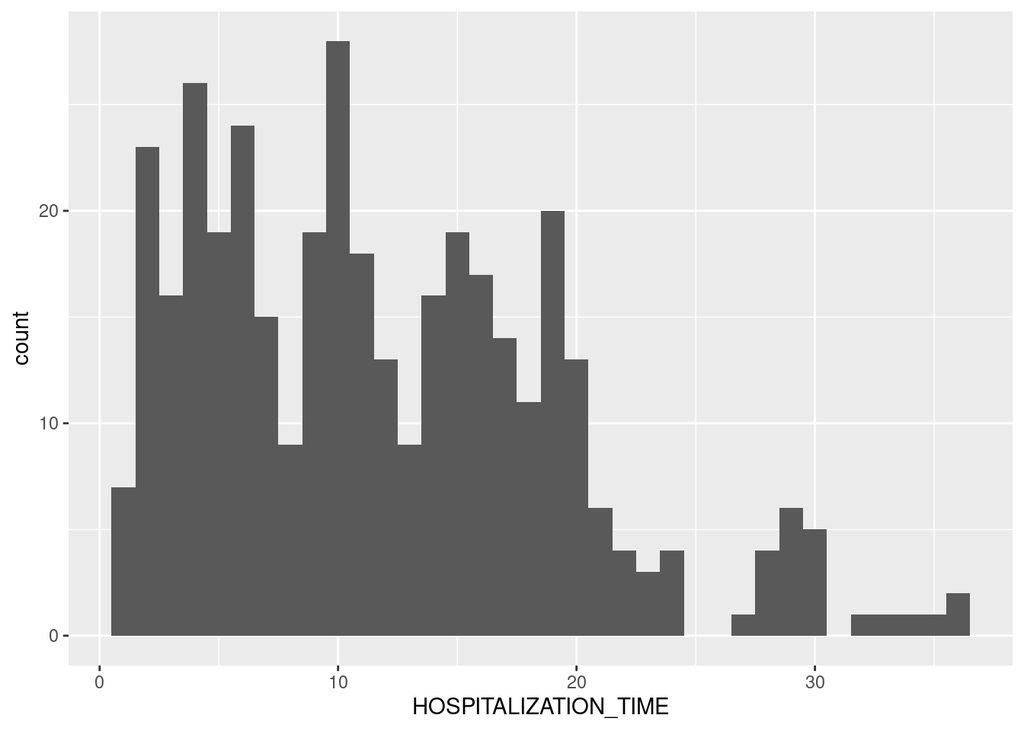

| OUTCOME | GENDER | AGE | HOSPITALIZATION_TIME |
| --- | --- | --- | --- |
| CURED | MALE | 54.5 | 15.0 days |
| CURED | FEMALE | 45.0 | 15.0 days |
| DECEASED | MALE | 68.0 | 7.0 days |
| DECEASED | FEMALE | 72.0 | 6.5 days |

### Wyniki badań

Pozostałe 74 kolumn zawiera wartości atrybutów, które reprezentują rodzaje miar zebranych podczas każdego badania.

Nazwy kolumn zostały poddane następującym transformacjom:

```r
df <- df %>%
  rename("NT-proBNP" = "Amino-terminal brain natriuretic peptide precursor(NT-proBNP)") %>%
  rename("2019-nCov-detection" = "2019-nCoV nucleic acid detection") %>%
  rename("aPPT" = "Activation of partial thromboplastin time") %>%
  rename("ALP" = "Alkaline phosphatase") %>%
  rename("AAT" = "aspartate aminotransferase") %>%
  rename("FDPs" = "Fibrin degradation products") %>%
  rename("ALT" = "glutamic-pyruvic transaminase") %>%
  rename("hs-CRP" = "High sensitivity C-reactive protein") %>%
  rename("hs-cTnI" = "Hypersensitive cardiac troponinI") %>%
  rename("HCV-abs-quant" = "HCV antibody quantification") %>%
  rename("HIV-abs-quant" = "HIV antibody quantification") %>%
  rename("INR" = "International standard ratio") %>%
  rename("LDH" = "Lactate dehydrogenase") %>%
  rename("MCH" = "mean corpuscular hemoglobin") %>%
  rename("MCHC" = "mean corpuscular hemoglobin concentration") %>%
  rename("MCV" = "mean corpuscular volume") %>%
  rename("MPV" = "Mean platelet volume") %>%
  rename("P-LCR" = "platelet large cell ratio") %>%
  rename("q-t-pallidum-abs" = "Quantification of Treponema pallidum antibodies") %>%
  rename("RCDW-SD" = "RBC distribution width SD") %>%
  rename("RBC_count" = "Red blood cell count") %>%
  rename("RCDW" = "Red blood cell distribution width") %>%
  rename("TNF-alfa" = "Tumor necrosis factorα") %>%
  rename("WBC_count" = "White blood cell count") %>%
  rename("gamma-GT" = "γ-glutamyl transpeptidase") %>%
  rename_with(~str_c(str_replace(.x, "\\(%\\)", ""), "_percent"), contains("(%)")) %>%
  rename_with(~str_replace(.x, "\\(#\\)", "")) %>%
  rename_with(tolower, matches("^[[:upper:]]{1}[[:lower:]]+", ignore.case = FALSE)) %>%
  rename_with(~str_replace_all(.x, "[ |-]", "_"))
str_sort(colnames(df[,-(1:7)]))
```

```
##  [1] "2019_nCov_detection"    "AAT"                    "albumin"
##  [4] "ALP"                    "ALT"                    "antithrombin"
##  [7] "aPPT"                   "basophil_count"         "basophil_percent"
## [10] "calcium"                "corrected_calcium"      "creatinine"
## [13] "D_D_dimer"              "direct_bilirubin"       "eGFR"
## [16] "eosinophil_count"       "eosinophils_percent"    "ESR"
## [19] "FDPs"                   "ferritin"               "fibrinogen"
## [22] "gamma_GT"               "globulin"               "glucose"
## [25] "HBsAg"                  "HCO3_"                  "HCV_abs_quant"
## [28] "hematocrit"             "hemoglobin"             "HIV_abs_quant"
## [31] "hs_CRP"                 "hs_cTnI"                "indirect_bilirubin"
## [34] "INR"                    "interleukin_10"         "interleukin_1β"
## [37] "interleukin_2_receptor" "interleukin_6"          "interleukin_8"
## [40] "LDH"                    "lymphocyte_count"       "lymphocyte_percent"
## [43] "MCH"                    "MCHC"                   "MCV"
## [46] "monocytes_count"        "monocytes_percent"      "MPV"
## [49] "neutrophils_count"      "neutrophils_percent"    "NT_proBNP"
## [52] "P_LCR"                  "PH_value"               "platelet_count"
## [55] "PLT_distribution_width" "procalcitonin"          "prothrombin_activity"
## [58] "prothrombin_time"       "q_t_pallidum_abs"       "RBC_count"
## [61] "RCDW"                   "RCDW_SD"                "serum_chloride"
## [64] "serum_potassium"        "serum_sodium"           "thrombin_time"
## [67] "thrombocytocrit"        "TNF_alfa"               "total_bilirubin"
## [70] "total_cholesterol"      "total_protein"          "urea"
## [73] "uric_acid"              "WBC_count"
```

## Czyszczenie zbioru danych

### Puste rekordy w zbiorze

W powyższej głównej zauważono wystąpienia wartości brakujących dla kolumny `RE_DATE`. Szybkie sprawdzenie wykazuje, że dla wierszy, gdzie nie ma atrybut `RE_DATE` przyjmuje wartość ‘NA’, wartości wszystkich atrybutów pochodzących z badań krwi, również przyjmują wartość ‘NA’.

```r
all(sapply(df[is.na(df$RE_DATE), -c(1,3:7)], is.na))
```

```
## [1] TRUE
```

Fakt, że wiersze te są właściwie puste, jest podstawą do ich usunięcia ze zbioru.

```r
df <- df[!is.na(df$RE_DATE),]
```

Po tej zmianie w zbiorze pozostało 6106 wierszy i 361 unikalnych identyfikatorów pacjentów.

### Kategorie badań

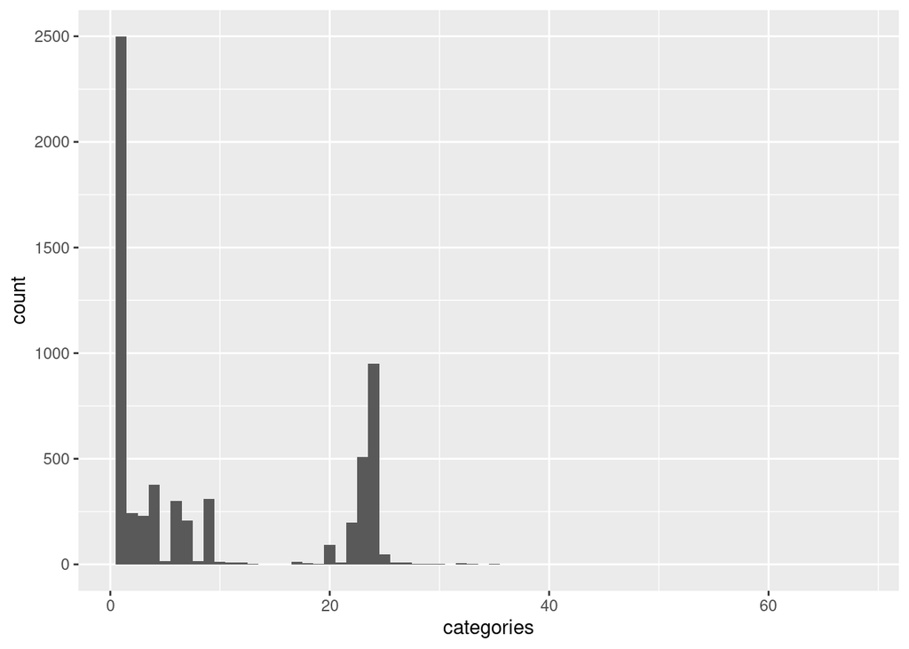

- prawie połowa rekordów ma zaledwie jeden wynik badania.
- co ciekawe, druga i trzecia pod względem liczości grupa rekordów ma odpowiednio po 24 i 23 elementy.
- Można dokonać analizy, czy te grupy powstają losowo, czy mają jakiś wspólny podzbiór -> analiza zbiorów częstych.

### Współwystępowanie kategorii

Zauważamy, że dużo NA, wynika to z tego, że badania są rozrzucone. Badanie zbiorów, czy któreś są częstsze niż inne.

```r
transactions <- sapply(df[,-(1:7)], function(x) !is.na(x))
```

Ilość unikalnych transakcji

```r
length(unique(apply(transactions, 1, function(x) which(x))))
```

```
## [1] 176
```

Szukamy maksymalnych domkniętych zbiorów częstych - sprawdzamy czy badania występują w grupach.

```r
itemsets <- apriori(transactions, parameter = list(target="closed frequent itemsets", support=.05, minlen=1, maxlen=30, maxtime=60))
```

```
## Apriori
##
## Parameter specification:
##  confidence minval smax arem  aval originalSupport maxtime support minlen
##          NA    0.1    1 none FALSE            TRUE      60    0.05      1
##  maxlen                   target  ext
##      30 closed frequent itemsets TRUE
##
## Algorithmic control:
##  filter tree heap memopt load sort verbose
##     0.1 TRUE TRUE  FALSE TRUE    2    TRUE
##
## Absolute minimum support count: 305
##
## set item appearances ...[0 item(s)] done [0.00s].
## set transactions ...[74 item(s), 6106 transaction(s)] done [0.00s].
## sorting and recoding items ... [63 item(s)] done [0.00s].
## creating transaction tree ... done [0.00s].
## checking subsets of size 1 2 3 4 5 6 7 8 9 10 11 12 13 14 15 16 17 18 19 20 21 22 23 24 done [27.58s].
## filtering closed item sets ... done [15.97s].
## sorting transactions ... done [0.00s].
## writing ... [130 set(s)] done [0.33s].
## creating S4 object  ... done [1.01s].
```

```r
mc_itemsets <- itemsets[is.maximal(itemsets)]
inspect(head(sort(mc_itemsets, by = 'support'), 10))
```

```
##      items                       support transIdenticalToItemsets count
## [1]  {hemoglobin,
##       eosinophils_percent,
##       basophil_percent,
##       platelet_count,
##       monocytes_percent,
##       RCDW,
##       neutrophils_percent,
##       MCV,
##       hematocrit,
##       WBC_count,
##       MCHC,
##       lymphocyte_count,
##       RBC_count,
##       eosinophil_count,
##       neutrophils_count,
##       MPV,
##       RCDW_SD,
##       lymphocyte_percent,
##       P_LCR,
##       monocytes_count,
##       PLT_distribution_width,
##       basophil_count,
##       MCH,
##       thrombocytocrit}        0.13609564                0.1354406   831
## [2]  {glucose}                0.12692434                0.0000000   775
## [3]  {serum_chloride,
##       ALP,
##       albumin,
##       total_bilirubin,
##       indirect_bilirubin,
##       total_protein,
##       urea,
##       corrected_calcium,
##       serum_potassium,
##       direct_bilirubin,
##       total_cholesterol,
##       AAT,
##       uric_acid,
##       HCO3_,
```

[output cut: 9 more lines]

```
## [4]  {hs_cTnI}                0.08303308                0.0000000   507
## [5]  {2019_nCov_detection}    0.08205044                0.0000000   501
## [6]  {NT_proBNP}              0.07779234                0.0000000   475
## [7]  {procalcitonin}          0.07517196                0.0000000   459
## [8]  {PH_value}               0.06288896                0.0000000   384
## [9]  {ESR}                    0.06272519                0.0000000   383
## [10] {prothrombin_time,
##       antithrombin,
##       prothrombin_activity,
##       fibrinogen,
##       thrombin_time,
##       D_D_dimer,
##       FDPs,
##       INR,
##       aPPT}                   0.05371765                0.0000000   328
```

Wyniki różnych testów prawdopodobnie pojawiały się w systemie o różnych porach, dlatego można je razem agregować.

### Badania poszczególnych pacjentów

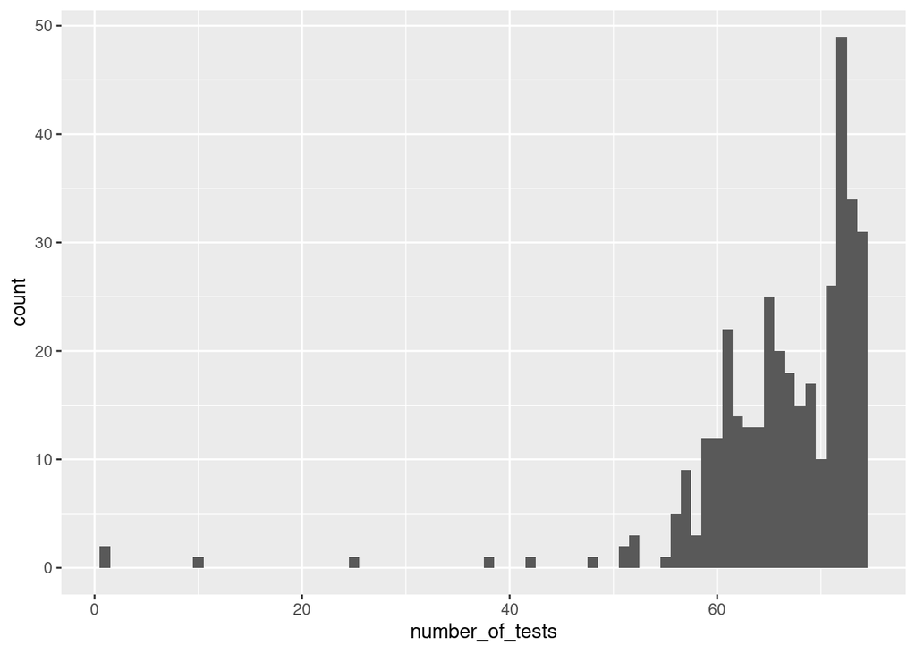

```r
patient_last_results <- df %>% group_by(PATIENT_ID) %>% fill(everything()) %>% summarise_all(last)
patient_last_results_count <- patient_last_results %>%
  rowwise() %>%
  mutate(number_of_tests=sum(!is.na(c_across(-(1:7)))), .after=OUTCOME)

ggplot(patient_last_results_count, aes(number_of_tests)) + geom_histogram(binwidth = 1)
```

Zauważamy, że część pacjentów ma niewiele przeprowadzonych rodzajów badań.

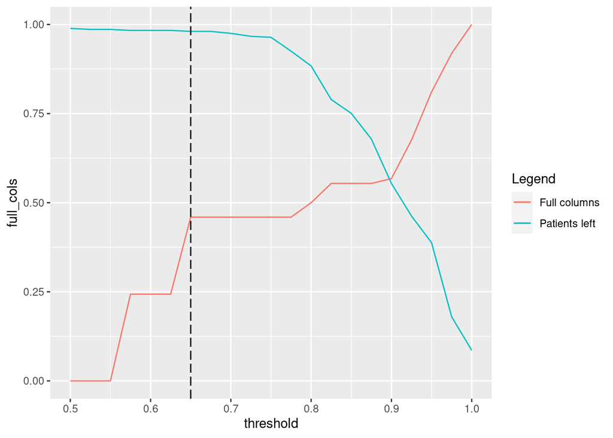

```r
veryfication_df <- function(n_tests, cols_cnt, th_seq) {
  cls_vec <- c()
  pts_vec <- c()
  for(th in th_seq) {
    tmp <- n_tests %>% filter(number_of_tests < cols_cnt*th)
    dt <- patient_last_results_count %>% filter(!(PATIENT_ID %in% tmp$PATIENT_ID))
    fl_cols <- mean(colSums(sapply(dt[,-(1:8)], is.na)) == 0)
    pnts <- length(unique(dt$PATIENT_ID)) / length(unique(n_tests$PATIENT_ID))
    cls_vec <- append(cls_vec, fl_cols)
    pts_vec <- append(pts_vec, pnts)
  }
    data.frame(threshold=th_seq, full_cols=cls_vec, patients_left=pts_vec)
}

to_plot <- veryfication_df(patient_last_results_count, ncol(df)-7, seq(0.5, 1.0, by=.025))

ggplot(to_plot, aes(x=threshold)) +
  geom_line(aes(y=full_cols, color="Full columns")) +
  geom_line(aes(y=patients_left, color="Patients left")) +
  labs(color="Legend") +
  geom_vline(xintercept=0.65, linetype = "longdash")
```

W zbiorze danych pozostawimy tylko tych, którzy mają ponad *0.65* wykonanych rodzajów badań.

```r
threshold <- 0.65
patients_to_be_removed <- patient_last_results_count %>%
  filter(number_of_tests < (ncol(df)-7) * threshold) %>%
  select(PATIENT_ID)

df <- df %>% filter(PATIENT_ID %!in% patients_to_be_removed$PATIENT_ID)
```

Po usunięciu rekordów pacjentów, u których przeprowadzono mało badań, pozostało 354 unikalnych pacjentów.

### Brakujące wartości w kategoriach

```r
knitr::kable(
df %>%
  group_by(PATIENT_ID) %>%
  fill(everything()) %>%
  summarise_all(last) %>%
  ungroup() %>%
  select(-(1:7)) %>%
  pivot_longer(everything()) %>%
  mutate(value=is.na(value)) %>%
  group_by(name) %>%
  summarize(value=sum(value), .groups="drop") %>%
  arrange(value)
)
```

| name | value |
| --- | --- |
| AAT | 0 |
| albumin | 0 |
| ALP | 0 |
| ALT | 0 |
| basophil_count | 0 |
| basophil_percent | 0 |
| creatinine | 0 |
| direct_bilirubin | 0 |
| eGFR | 0 |
| eosinophil_count | 0 |
| eosinophils_percent | 0 |
| gamma_GT | 0 |
| globulin | 0 |
| HCO3_ | 0 |
| hematocrit | 0 |
| hemoglobin | 0 |
| LDH | 0 |
| lymphocyte_count | 0 |
| lymphocyte_percent | 0 |
| MCH | 0 |
| MCHC | 0 |
| MCV | 0 |
| monocytes_count | 0 |
| monocytes_percent | 0 |
| neutrophils_count | 0 |
| neutrophils_percent | 0 |
| platelet_count | 0 |
| RBC_count | 0 |
| total_bilirubin | 0 |
| total_cholesterol | 0 |
| total_protein | 0 |
| urea | 0 |
| uric_acid | 0 |
| WBC_count | 0 |
| indirect_bilirubin | 1 |
| calcium | 2 |
| serum_chloride | 2 |
| serum_potassium | 2 |
| serum_sodium | 2 |
| corrected_calcium | 3 |
| hs_CRP | 3 |
| glucose | 5 |
| INR | 5 |
| prothrombin_activity | 5 |
| prothrombin_time | 5 |
| RCDW | 6 |
| RCDW_SD | 6 |
| MPV | 10 |
| P_LCR | 10 |
| PLT_distribution_width | 10 |
| thrombocytocrit | 10 |
| D_D_dimer | 14 |
| procalcitonin | 44 |
| aPPT | 59 |
| fibrinogen | 59 |
| thrombin_time | 59 |
| ESR | 69 |
| hs_cTnI | 69 |
| HBsAg | 82 |
| HCV_abs_quant | 82 |
| q_t_pallidum_abs | 82 |
| HIV_abs_quant | 83 |
| NT_proBNP | 90 |
| PH_value | 126 |
| interleukin_6 | 138 |
| 2019_nCov_detection | 140 |
| interleukin_1β | 140 |
| interleukin_2_receptor | 140 |
| interleukin_8 | 140 |
| TNF_alfa | 140 |
| interleukin_10 | 141 |
| ferritin | 143 |
| antithrombin | 153 |
| FDPs | 153 |

## Dodatkowe cechy

```r
df <- df %>%
  mutate(DAYS_TO_OUTCOME = as.numeric(difftime(
    floor_date(DISCHARGE_TIME, "1 day"),
    floor_date(RE_DATE, "1 day"), unit="days"
    ), unit="days"), .before=OUTCOME)
df %>% summarise(DAYS_TO_OUTCOME = quantile(DAYS_TO_OUTCOME, c(0, 0.25, 0.5, 0.75,1)), quantile = c("min", "1st", "2nd", "3rd", "max"))
```

```
## # A tibble: 5 x 2
##   DAYS_TO_OUTCOME quantile
##             <dbl> <chr>
## 1              -2 min
## 2               3 1st
## 3               7 2nd
## 4              13 3rd
## 5              35 max
```

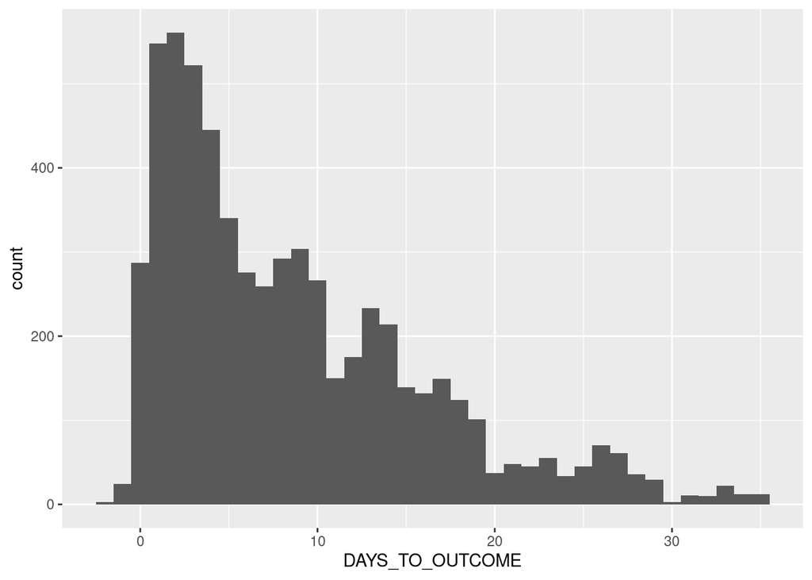

```r
ggplot(df, aes(DAYS_TO_OUTCOME)) + geom_histogram(binwidth = 1)
```

### Agregacja wierszy według daty badania

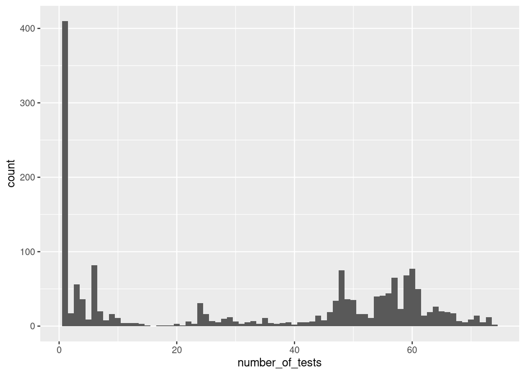

```r
df <- df %>%
  mutate(RE_DATE = floor_date(RE_DATE, '1 day')) %>%
  group_by(PATIENT_ID, RE_DATE) %>%
  fill(everything()) %>%
  summarise_all(last) %>%
  ungroup() %>%
  rowwise() %>%
  mutate(number_of_tests=sum(!is.na(c_across(-(1:8)))), .after=OUTCOME)
ggplot(df, aes(number_of_tests)) + geom_histogram(binwidth = 1)
```

```r
df <- df %>% select(-number_of_tests)
```

# Zbiór danych

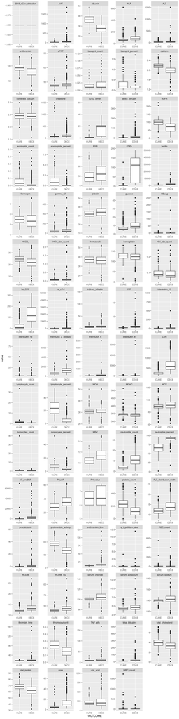

```r
ggplot(
  df %>% pivot_longer(hs_cTnI:creatinine) %>% filter(!is.na(value)),
  aes(x=OUTCOME, y=value)
) + geom_boxplot() +
scale_x_discrete(labels = abbreviate) +
facet_wrap(name ~ ., scales="free",ncol=5)
```

# Korelacja

```r
cor_mat <- cor(
  x = df %>% select(-c(1:2,4:8)),
  y = df %>% mutate(isCURED=OUTCOME=="CURED") %>% select(isCURED),
  use="pairwise.complete.obs"
  )
knitr::kable(
data.frame(round(cor_mat,2)) %>% arrange(desc(abs(isCURED))) %>% head(15)
)
```

|  | isCURED |
| --- | --- |
| neutrophils_percent | -0.73 |
| lymphocyte_percent | 0.72 |
| albumin | 0.69 |
| prothrombin_activity | 0.65 |
| hs_CRP | -0.65 |
| D_D_dimer | -0.64 |
| LDH | -0.63 |
| neutrophils_count | -0.61 |
| FDPs | -0.60 |
| AGE | -0.58 |
| calcium | 0.57 |
| platelet_count | 0.54 |
| monocytes_percent | 0.54 |
| eGFR | 0.49 |
| urea | -0.48 |

```r
knitr::kable(
tidy(cor.test(df$LDH, as.numeric(df$OUTCOME=="CURED")))
)
```

| estimate | statistic | p.value | parameter | conf.low | conf.high | method | alternative |
| --- | --- | --- | --- | --- | --- | --- | --- |
| -0.6270327 | -24.33491 | 0 | 914 | -0.6648056 | -0.5860615 | Pearson’s product-moment correlation | two.sided |

```r
correlations <- df %>% mutate(isCURED=as.numeric(OUTCOME=="CURED")) %>% select(-c(1:2,4:8)) %>%
  pivot_longer(!isCURED, names_to="attribute", values_to="x_val") %>%
  filter(!is.na(x_val)) %>%
  nest(data = c(x_val, isCURED)) %>%
  mutate(cor_test = map(data, ~tidy(cor.test(.x$x_val, .x$isCURED)))) %>%
  unnest(cor_test) %>%
  select(attribute, estimate, p.value, conf.low, conf.high) %>%
  arrange(desc(abs(estimate))) %>% head(15)
knitr::kable(
correlations
)
```

| attribute | estimate | p.value | conf.low | conf.high |
| --- | --- | --- | --- | --- |
| neutrophils_percent | -0.7301461 | 0 | -0.7586392 | -0.6988654 |
| lymphocyte_percent | 0.7234883 | 0 | 0.6915912 | 0.7525691 |
| albumin | 0.6880859 | 0 | 0.6524294 | 0.7207028 |
| prothrombin_activity | 0.6547754 | 0 | 0.6084767 | 0.6966318 |
| hs_CRP | -0.6509896 | 0 | -0.6910468 | -0.6069460 |
| D_D_dimer | -0.6376192 | 0 | -0.6819778 | -0.5885867 |
| LDH | -0.6270327 | 0 | -0.6648056 | -0.5860615 |
| neutrophils_count | -0.6083675 | 0 | -0.6470960 | -0.5665074 |
| FDPs | -0.6042409 | 0 | -0.6689583 | -0.5304310 |
| AGE | -0.5761382 | 0 | -0.6071595 | -0.5433633 |
| calcium | 0.5703332 | 0 | 0.5257539 | 0.6117881 |
| platelet_count | 0.5419441 | 0 | 0.4952125 | 0.5855487 |
| monocytes_percent | 0.5415337 | 0 | 0.4947996 | 0.5851444 |
| eGFR | 0.4909936 | 0 | 0.4402769 | 0.5385870 |
| urea | -0.4841428 | 0 | -0.5321758 | -0.4330031 |

# Techniczne

## Wszytkie użyte pakiety

```r
unique(c(.packages(), loadedNamespaces()))
```

```
##  [1] "broom"      "purrr"      "ggplot2"    "stringr"    "lubridate"
##  [6] "dplyr"      "tidyr"      "arules"     "Matrix"     "httr"
## [11] "readxl"     "stats"      "graphics"   "grDevices"  "utils"
## [16] "datasets"   "methods"    "base"       "Rcpp"       "highr"
## [21] "cellranger" "compiler"   "pillar"     "tools"      "digest"
## [26] "evaluate"   "lifecycle"  "tibble"     "gtable"     "lattice"
## [31] "pkgconfig"  "rlang"      "cli"        "curl"       "yaml"
## [36] "xfun"       "withr"      "knitr"      "generics"   "vctrs"
## [41] "grid"       "tidyselect" "glue"       "R6"         "fansi"
## [46] "rmarkdown"  "farver"     "magrittr"   "backports"  "scales"
## [51] "htmltools"  "ellipsis"   "assertthat" "colorspace" "labeling"
## [56] "utf8"       "stringi"    "munsell"    "crayon"
```